# Consumo de cerveja

Ben-Hur Santana de Lima

21/04/2021

## Carregando o banco de dados

```r
df <- read.csv2("consumo_cerveja.csv")
```

## Pacotes utilizados

```r
library(dplyr)
library(ggplot2)
library(lubridate)
library(kableExtra)
library(dgof)
```

## Renomeando variaveis

Como as variáveis do banco de dados estão nomeadas com " espaço " o R converte a leitura e ficou “estranho” a parte em que continha a escala das variávies, então decidi renomea-los para ficar melhor fazer os códigos. Mas lembrando que Temperatura Média, mínima e máxima está em graus Celsius, a Precipitação está em mm, e o consumo de cerveja está em litros.

```r
df<-df%>%
    dplyr::rename(Temperatura.Media = Temperatura.Media..C.,Temperatura.Minima = Temperatura.Minima..C.,Temperatura.Maxima = Temperatura.Maxima..C., Precipitacao=Precipitacao..mm., Consumo.de.cerveja=Consumo.de.cerveja..litros.)
```

```r
df%>%
  sample_n(5)
```

```
##         Data Temperatura.Media Temperatura.Minima Temperatura.Maxima
## 1 25/09/2019             23.24               19.2               30.3
## 2 27/12/2019             24.00               21.1               28.2
## 3 04/11/2019             21.52               18.6               27.4
## 4 03/06/2019             17.94               15.0               21.7
## 5 23/10/2019             20.50               17.6               27.3
##   Precipitacao Final.de.Semana Consumo.de.cerveja
## 1          0.0               0              29411
## 2         13.6               1              32307
## 3          6.8               0              21479
## 4          0.0               0              21055
## 5         13.4               0              26594
```

## Análise Descritiva

A principio não ia fazer uma analise descritiva para as Temperaturas, pois elas já estavam com as métricas estatisticas Media, Minima, e Maxima. Porém os dados nos fornecem essas métricas diariamente, uma tabela mostrando do ano todo nos daria outra visão. Como por exemplo, podemos ver que há 1 NA em cada uma delas.

Note também que a variável Data está no formato de de character, quero deixo-lo no formato de Date.

```r
a<-summary(df)
 kableExtra::kable(a) %>%
  kable_styling("striped")
```

|  | Data | Temperatura.Media | Temperatura.Minima | Temperatura.Maxima | Precipitacao | Final.de.Semana | Consumo.de.cerveja |
| --- | --- | --- | --- | --- | --- | --- | --- |
|  | Length:365 | Min. :12.90 | Min. :10.60 | Min. :14.50 | Min. : 0.000 | Min. :0.0000 | Min. :14343 |
|  | Class :character | 1st Qu.:19.00 | 1st Qu.:15.30 | 1st Qu.:23.80 | 1st Qu.: 0.000 | 1st Qu.:0.0000 | 1st Qu.:22008 |
|  | Mode :character | Median :21.37 | Median :17.90 | Median :26.90 | Median : 0.000 | Median :0.0000 | Median :24867 |
|  | NA | Mean :21.29 | Mean :17.47 | Mean :26.61 | Mean : 5.197 | Mean :0.2849 | Mean :25401 |
|  | NA | 3rd Qu.:23.29 | 3rd Qu.:19.60 | 3rd Qu.:29.40 | 3rd Qu.: 3.200 | 3rd Qu.:1.0000 | 3rd Qu.:28631 |
|  | NA | Max. :52.86 | Max. :24.50 | Max. :36.50 | Max. :94.800 | Max. :1.0000 | Max. :37937 |
|  | NA | NA’s :1 | NA’s :1 | NA’s :1 | NA | NA | NA |

Para resolver o problema dos NA nas colunas de temperatura, podemos substitui-las pelas suas respectivas medianas. O dplyr possui uma função chamada coalesce que serve exatamente para isto.

```r
df$Temperatura.Media <- coalesce(df$Temperatura.Media, median(df$Temperatura.Media, na.rm = T))
df$Temperatura.Minima <- coalesce(df$Temperatura.Minima, median(df$Temperatura.Minima, na.rm = T))
df$Temperatura.Maxima <- coalesce(df$Temperatura.Maxima, median(df$Temperatura.Maxima, na.rm = T))
```

No caso para mudar o tipo de variavel de data utilizaremos o comando dmy() (dia, mês, ano), do pacote lubridate. Se o formato da data estivesse mês/dia/ano podiamos usar o mdy(), e assim por diante.

```r
df$Data = dmy(paste(df$Data))
```

## Análise Exploratória

Podemos analisar a data com a variavel final de semana, para estudar se existe mais consumo de cerveja durante os dias de semana ou finais de semana(0 para dias de semana,1 para finais de semana). No gráfico abaixo é possivel perceber que finais de semana são mais propensos ao alto consumo de alcool.

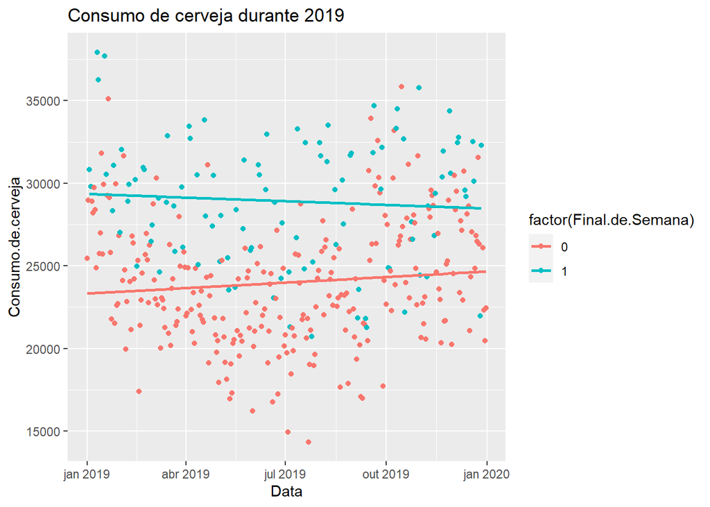

```r
par(mfrow = c(1,2))

df %>%
  ggplot(aes( Data,Consumo.de.cerveja, color= factor(Final.de.Semana))) +
  geom_point(aes(color=factor(Final.de.Semana))) +
  geom_smooth(method = "lm", se=F) +
  labs(title = "Consumo de cerveja durante 2019")
```

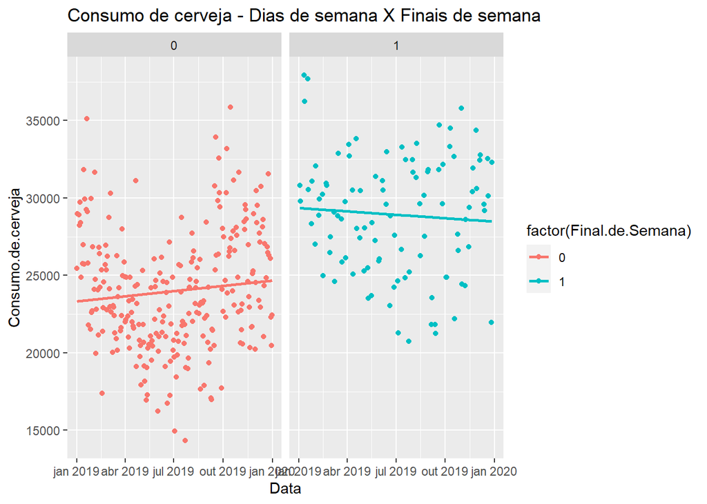

```r
df %>%
  ggplot(aes( Data,Consumo.de.cerveja, color= factor(Final.de.Semana))) +
  geom_point() +
  facet_wrap(vars(color=factor(Final.de.Semana))) +
  geom_smooth(method = "lm", se=F) +
  labs(title = "Consumo de cerveja - Dias de semana X Finais de semana")
```

No boxplot abaixo podemos confirmar o que foi dito anteriormente, finais de semana superam os dias de semana em questão de consumo de cerveja.

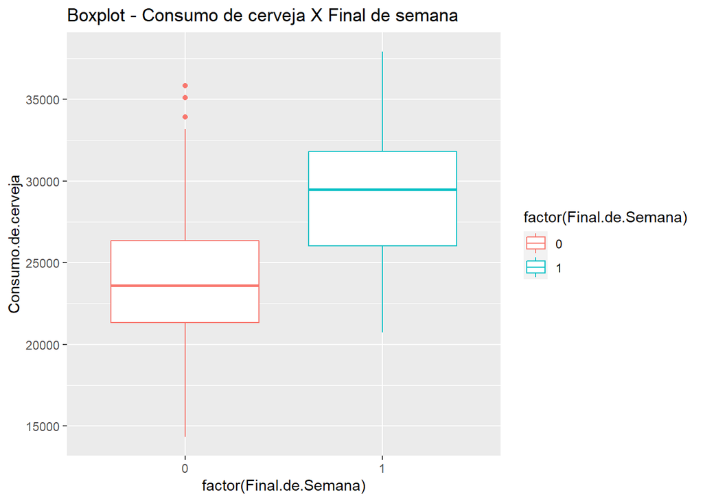

```r
df %>%
  ggplot(aes(factor(Final.de.Semana),Consumo.de.cerveja,color= factor(Final.de.Semana) )) +
  geom_boxplot()+
  labs(title = "Boxplot - Consumo de cerveja X Final de semana")
```

Vimos no summary algumas métricas estatisticas, pensei criar uma nova variável com temperaturas categoricas e será baseada na coluna Temperatura.Media. Essa nova variável se chamará Temperatura e terá três categorias: Baixa, Media, Alta. Se a temperatura média estiver abaixo de 20 graus eu digo que ela está baixa, se estiver entre 20 e 23 graus está na média e se estiver maior que 23 graus está alta(os valores podem ser discutidos).

```r
df <- df %>%
  dplyr::mutate(Temperatura = dplyr::case_when(Temperatura.Media <= "20.0" ~ "Baixa",
                                            Temperatura.Media >= "20.1" & Temperatura.Media <= "23.0" ~ "Media",
                                            Temperatura.Media >= "23.1" ~ "Alta"
                                            ))
```

Agora podemos ter uma média do consumo de cerveja de acordo com a temperatura, como por exemplo é mais propcio consumir mais quando a temperatura está alta, em geral no começo e fim de ano que são as épocas mais quentes. No meio do ano há casos com muito consumo mas a grande concentração está abaixo dos 25.000 litros.

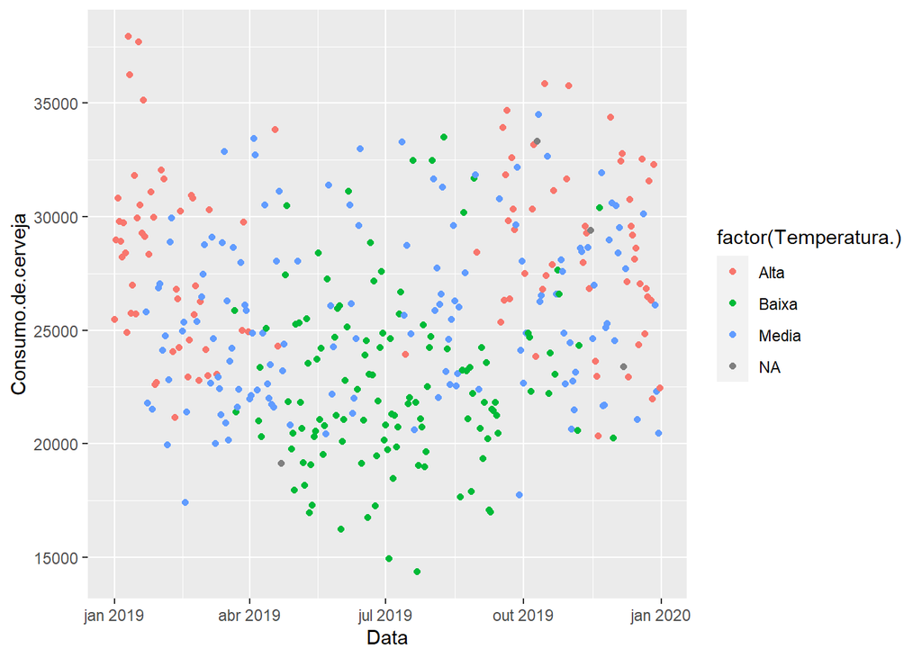

```r
df %>%
  ggplot(aes( Data,Consumo.de.cerveja, color= factor(Temperatura.))) +
  geom_point(aes(color=factor(Temperatura)))
```

## Regressão Linear

Pensei em fazer um modelo de regressão para prever o consumo médio de cerveja de acordo com as temperaturas: $Consumo$ ~ $Temperatura.Média + Temperatura.Minima + Temperatura.Maxima$.

Abaixo temos o histograma de nossa variável resposta e a densidade de sua função, ela apararenta ter uma distribuição normal mas podemos fazer testes para confirmar isso.

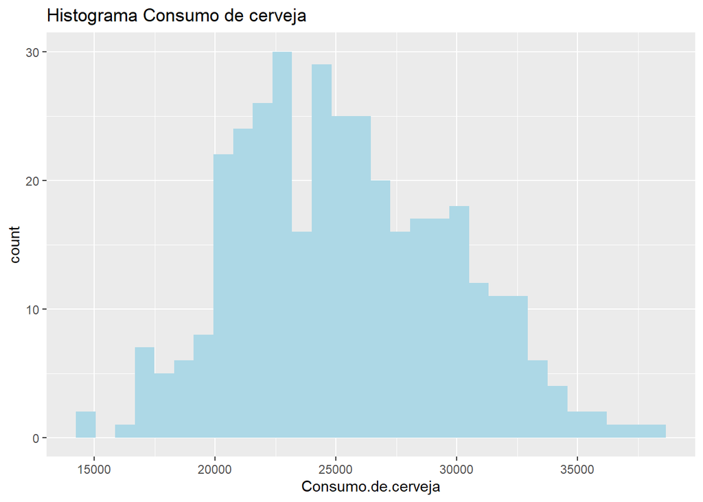

```r
df %>%
  ggplot(aes(Consumo.de.cerveja)) +
  geom_histogram(bins = 30, fill = "lightblue") +
  labs(title = "Histograma Consumo de cerveja")
```

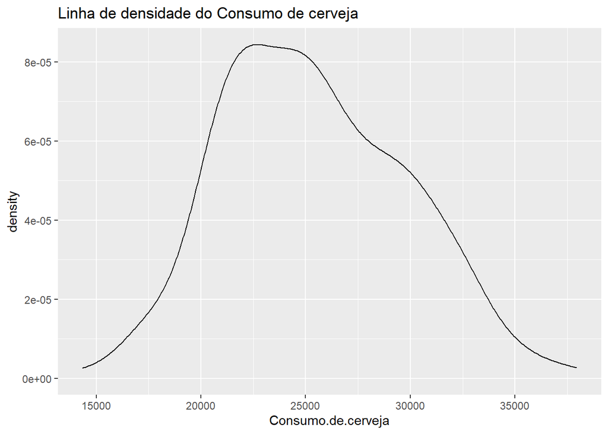

```r
df %>%
  ggplot(aes(Consumo.de.cerveja)) +
  geom_density() +
  labs(title = "Linha de densidade do Consumo de cerveja")
```

A hipotese nula do teste de shapiro-wilk é que a população possui distribuição normal. Portanto, se o p-valor for < 0.05 rejeitamos a hipotese nula, como nosso p-value = 0.005 então nossa variável não possui distribuição normal.

```r
shapiro.test(df$Consumo.de.cerveja)
```

```
##
##  Shapiro-Wilk normality test
##
## data:  df$Consumo.de.cerveja
## W = 0.98855, p-value = 0.005779
```

Se fizermos um gráfico de dispersão das temperaturas em relação ao consumo de cerveja podemos observar um possivel outlier no gráfico da temperatura média, os pontos da temperatura mínima são bem distribuidos e o grafico da temperatura máxima apresenta uma tendência de crescimento.

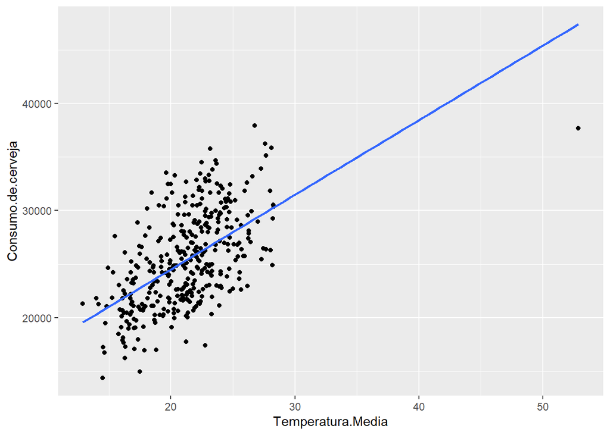

```r
df %>%
  ggplot(aes( Temperatura.Media,Consumo.de.cerveja)) +
  geom_point() +
  geom_smooth(method = "lm", se=F)
```

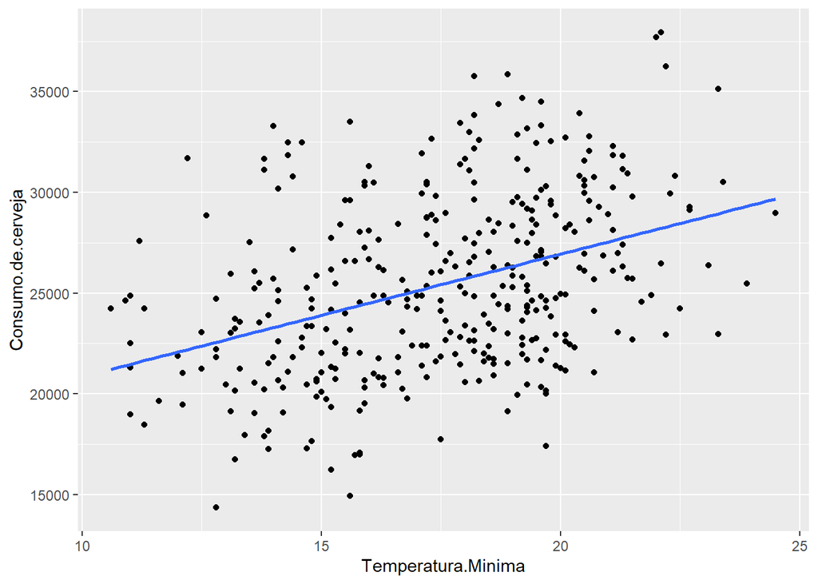

```r
df %>%
  ggplot(aes( Temperatura.Minima,Consumo.de.cerveja)) +
  geom_point() +
  geom_smooth(method = "lm", se=F)
```

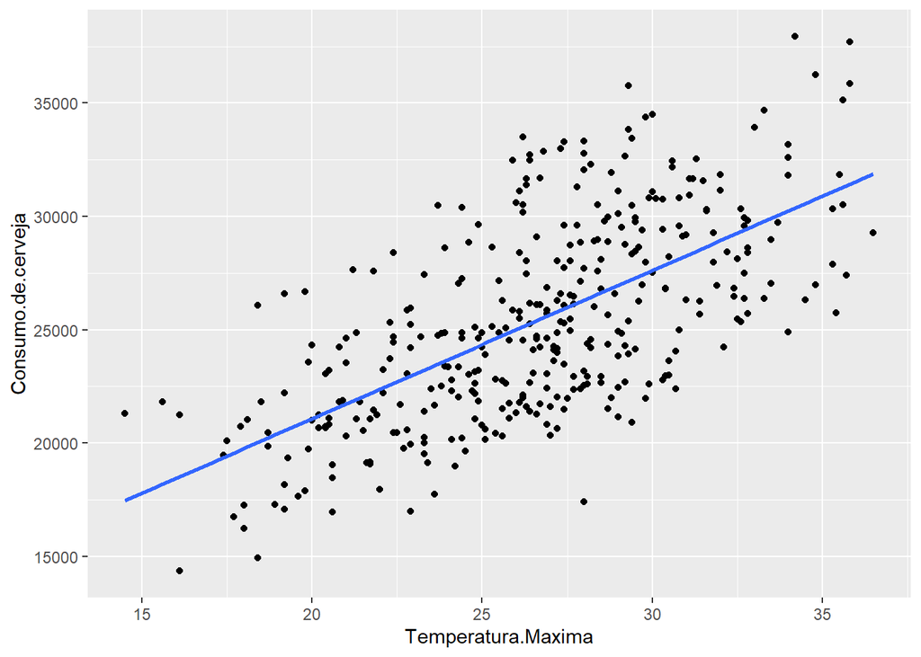

```r
df %>%
  ggplot(aes( Temperatura.Maxima,Consumo.de.cerveja)) +
  geom_point() +
  geom_smooth(method = "lm", se=F)
```

Ao fazer uma correlação das temperaturas com o consumo de cerveja vemos númericamente o que o gráfico de dispersão acima nos mostra.

```r
cor(df$Consumo.de.cerveja, df$Temperatura.Media)
```

```
## [1] 0.564636
```

```r
cor(df$Consumo.de.cerveja, df$Temperatura.Minima)
```

```
## [1] 0.3899424
```

```r
cor(df$Consumo.de.cerveja, df$Temperatura.Maxima)
```

```
## [1] 0.6428027
```

Na coluna Estime, no summary abaixo, nos mostra quanto quanto cada variável agrega para o consumo de cerveja. Por exemplo,a cada unidade da temperatura media temos um acrescimo de 192.20 litros de consumo, já a temperatura mínima contribui negativamente com -209.70 litros de consumo, a cada unidade, e a cada unidade da temperatura máxima se obtem mais 609.93 litros.(Seria muito bom fazer essa previsão no shiny)

A última coluna Pr(>|t|) representa o nível de significância, se o valor for menor que 0.05, a única variável não relevante para o modelo é a temperatura média. Provavelmente por causa do possivel outlier que identificamos no gráfico de dispersão.

Além disso o summary nos mostra o coeficiente de determinação, o $R^2$. Ele indica quanto o modelo está explicando nossa variável resposta(Consumo de cerveja), no nosso caso $R^2 = 41.54\%$.

```r
model = lm( df$Consumo.de.cerveja ~ df$Temperatura.Media + df$Temperatura.Minima + df$Temperatura.Maxima, data = df)
summary(model)
```

```
##
## Call:
## lm(formula = df$Consumo.de.cerveja ~ df$Temperatura.Media + df$Temperatura.Minima +
##     df$Temperatura.Maxima, data = df)
##
## Residuals:
##     Min      1Q  Median      3Q     Max
## -8661.8 -2694.3  -370.7  2251.6  8532.0
##
## Coefficients:
##                       Estimate Std. Error t value Pr(>|t|)
## (Intercept)            8739.45    1207.61   7.237 2.78e-12 ***
## df$Temperatura.Media    192.20     120.25   1.598   0.1108
## df$Temperatura.Minima  -209.70     103.53  -2.025   0.0436 *
## df$Temperatura.Maxima   609.93      80.75   7.553 3.52e-13 ***
## ---
## Signif. codes:  0 '***' 0.001 '**' 0.01 '*' 0.05 '.' 0.1 ' ' 1
##
## Residual standard error: 3364 on 361 degrees of freedom
## Multiple R-squared:  0.4202, Adjusted R-squared:  0.4154
## F-statistic: 87.21 on 3 and 361 DF,  p-value: < 2.2e-16
```

### Análise de Diagnostico do modelo

A análise de diagnostico é importante para sabermos se nosso modelo é válido, nele estamos basicamente estudando os resíduos do modelo, como por exemplo se eles são independentes, se são homocedasticos(possuem a variância constante) e se possuem distribuição normal.

As linhas de código abaixo servem para encontrar a matriz do modelo ajustado, o estimador dessa matriz e os residuos studentizados. Assim como vão nos auxiliar a fazer alguns gráficos ao decorrer da analise.

```r
fit.model <- model #modelo ajustado
X <- model.matrix(fit.model) #matriz do modelo ajustado
n <- nrow(X) #no de observações
p <- ncol(X) #no de parâmetros
H <- X%*%solve(t(X)%*%X)%*%t(X) #matriz Hat
h <- diag(H) #diagonal da matriz Hat (hii, medida de alavanca)
rs = rstudent(model) # residuo studentizado
```

O primeiro gráfico que falaremos é o da distância de cook, ele nos ajuda a verificar os pontos de alavancagem, que causam aleração na inclinação da reta do modelo. Nosso gráfico apresenta apenas um, provavelmente aquele que identificamos na analise exploratória.

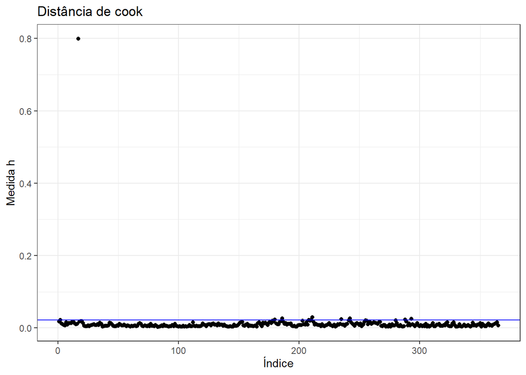

```r
h <- data.frame(h = h, i = c(1:(length(h))))
plot <- ggplot(h, aes(i, h)) + geom_point() + xlab("Índice") + ylab("Medida h") + theme_bw() +
   geom_abline(slope = 0, intercept = 2*p/n, col = "blue", type = "dashed")
  plot + labs(title = "Distância de cook")
```

Falaremos agora sobre resíduos studentizados pelo índice, que serve para verificar se os erros são independentes entre si. Vemos que no gráfico os pontos estão bem homogeneos entre o intervalo [-2,2], com alguns pontos discrepantes aos que estão fora deste intervalo, então temos informações para não rejeitar a hipotese de independencia.

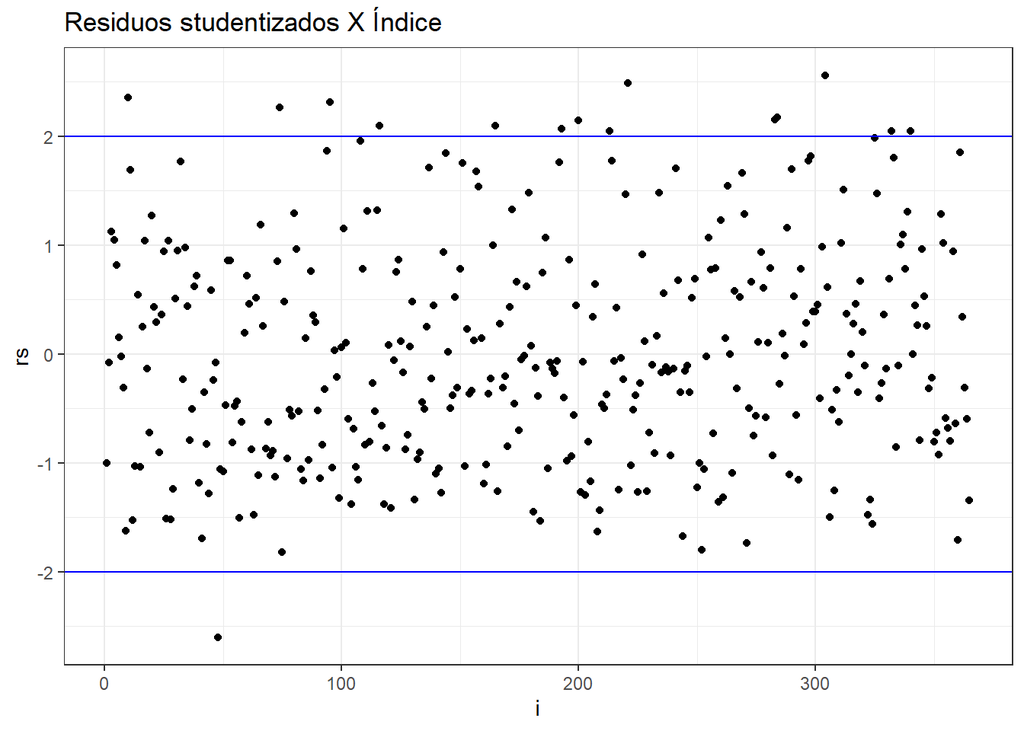

```r
rs <- data.frame(rs = rs, i = c(1:length(rs)))
plot <- ggplot(rs, aes(i, rs)) + geom_point() + theme_bw() + geom_hline(yintercept = -2, col = "blue")+
    geom_hline(yintercept = 2, col = "blue")
plot + labs(title = "Residuos studentizados X Índice")
```

Para testar a homocedasticidade(se os residuos possuem variância constante) vamos ver o gráfico dos resíduos studentizados x valores ajustados, como nosso gráfico está com os pontos bem distribuidos temos informações para não rejeitar a hipotese de que os residuos são homocedasticos. Geralmente rejeitamos este tipo de hipotese caso os dados estivessem muito concentrados em uma parte especifica, ou formato de cone, etc.

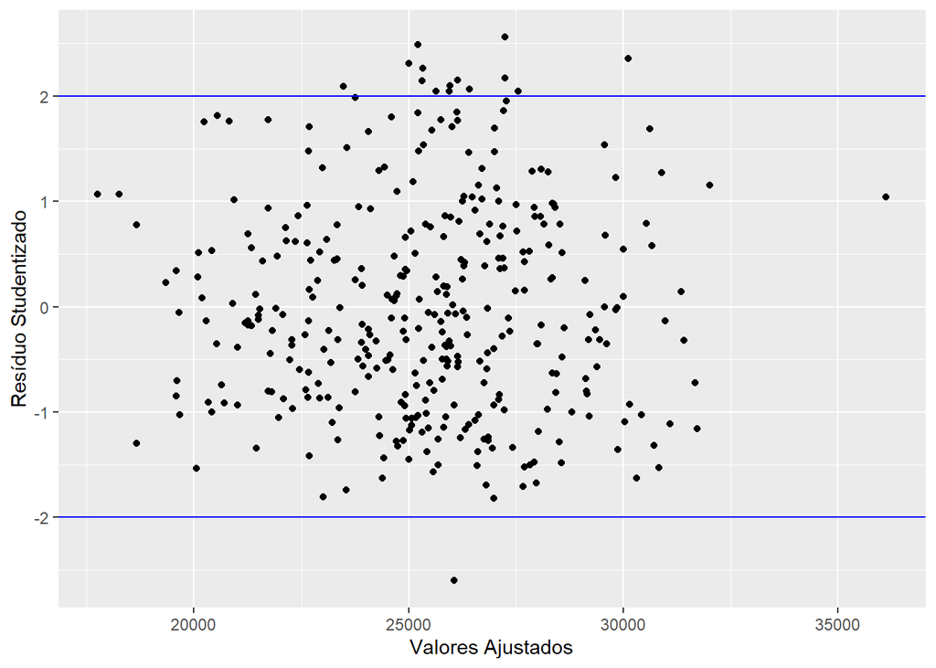

```r
homocedasticidade <- data.frame(rs = rs$rs, fit = fit.model$fitted)
ggplot(homocedasticidade, aes(fit, rs)) + geom_point() + geom_hline(yintercept = -2, col = "blue") + geom_hline(yintercept = 2, col = "blue") + xlab("Valores Ajustados") + ylab("Resíduo Studentizado")
```

Como última análise dos resíduos vamos observar a normalidade atráves de um gráfico de envelope, onde onde ele mostra um qqplot com intervalos de confiança. Pelo gráfico se todos os pontos estivessem dentro deste intervalo de confiança teriamos motivos parar não rejeitar a hipotese de normalidade, mas como não é o nosso caso não podemos.

```r
qqnormb <- function(X, Y, Z){
li <- qqnorm(X, plot.it = F)
 x <- qqnorm(Y, plot.it = F)
 ls <- qqnorm(Z, plot.it = F)

 data <- data.frame(lix = li$x, liy = li$y, xx= x$x, xy = x$y ,lsx = ls$x, lsy = ls$y)

require(ggplot2)
 p <- ggplot(data, aes(lix,liy, xx,xy, lsx,lsy)) + geom_ribbon(aes(ymin = liy, ymax = lsy), alpha = 0.3, col = "grey") + geom_point(aes(xx, xy))
 return(p)
}


par(mfrow=c(1,1))
X <- model.matrix(fit.model)
n <- nrow(X)
p <- ncol(X)
H <- X%*%solve(t(X)%*%X)%*%t(X)
h <- diag(H)
si <- lm.influence(fit.model)$sigma
r <- resid(fit.model)
tsi <- r/(si*sqrt(1-h))
#
ident <- diag(n)
epsilon <- matrix(0,n,100)
e <- matrix(0,n,100)
e1 <- numeric(n)
e2 <- numeric(n)
#
for(i in 1:100){
 epsilon[,i] <- rnorm(n,0,1)
 e[,i] <- (ident - H)%*%epsilon[,i]
 u <- diag(ident - H)
 e[,i] <- e[,i]/sqrt(u)
 e[,i] <- sort(e[,i]) }
#
for(i in 1:n){
 eo <- sort(e[i,])
 e1[i] <- (eo[2]+eo[3])/2
 e2[i] <- (eo[97]+eo[98])/2 }
#
med <- apply(e,1,mean)
faixa <- range(tsi,e1,e2)
```

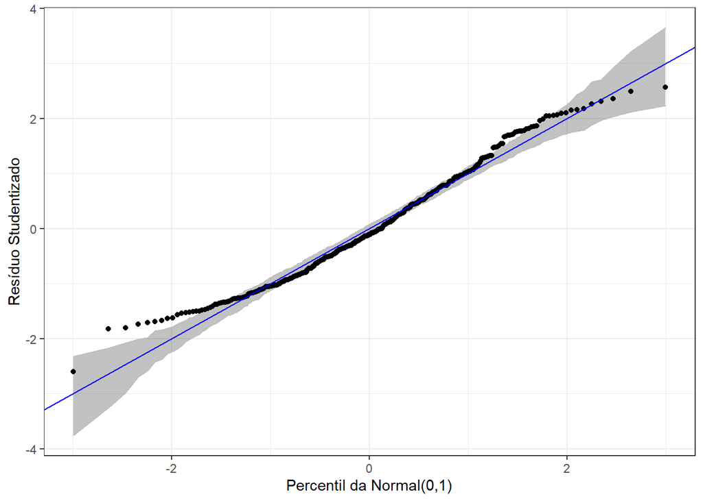

```r
qqnormb(e1, tsi, e2) + theme_bw() + xlab("Percentil da Normal(0,1)") + ylab("Resíduo Studentizado") + geom_abline(slope = 1, intercept = 0, col = "blue")
```

Mas podemos fazer um teste de normalidade para confirmar o caso. Usando o pacote tseries, a função jarque.bera.test() usa o teste de Bera-Jarque com a hipotese nula de que os residuos tem distribuição normal, e como o p-value de nosso teste de 0.002362 < 0.05, rejeitamos esta hipotese.

```r
library(tseries)
jarque.bera.test(residuals(model))
```

```
##
##  Jarque Bera Test
##
## data:  residuals(model)
## X-squared = 12.096, df = 2, p-value = 0.002362
```

## Conclusão

Neste Relatório abordei inicialmente uma análise descritiva e exploratória afimm de conhecer melhor o conjunto de dados que estava trabalhando. Em seguida falei um pouco da ideia do modelo de regressão que me veio a mente, além de alguns tópicos da análise de diagnóstico de nosso modelo, como Observações atípicas, Normalidade e Homocedasticidade.

A principio pensei em fazer um modelo de séries temporais por causa variável Data, do banco de dados, para prever como seria o consumo de cerveja alguns dias depois. Mas um modelo de regressão linear seria perfeito para prever esse mesmo consumo de acordo com a temperatura da cidade.

Na análise de diagnostico tivemos alguns problemas. Vimos na análise descritiva que existiam alguns possivel outliers, que foi confirmado a presença dele no gráfico da Distância de Cook, além da distribuição dos nosso resíduos não serem normalmente distribuidos, nos demais gráficos nosso modelo parece apresentavel.

Portanto, apresentando um coeficiente de determinação não muito alto, e pela falha na normalização dos resíduos, esse modelo não é valido. Podendo ser resolvido com alguma transformação de normalidade, ou testando outros modelos.